# Beta Diversity

## QIIME on UNIX

Read the [Beta Diversity QIIME Tutorial on Moodle](https://ay15.moodle.umn.edu/mod/resource/view.php?id=1314198)

### Possible Errors

“beta_diversity_through_plots.py: error: Output directory already exists. Please choose a different directory, or force overwrite with -f.”

For this error, you must remove your output directory (specified by -o). You can delete it through FileZilla. Do this and then re-run the program.

### My PBS Script. Feel free to use it

But change the PBS -o and PBS -e lines or I will not be able to help you. Do not forget the PBS Header from one of your previous scripts (that worked)!

> cd /home/bioltrm1/guhli007  
> module load qiime/1.8.0

> beta_diversity_through_plots.py \  
> -i /home/bioltrm1/shared/otu_rare2000.biom \  
> -o beta_diversity \  
> -t /home/bioltrm1/shared/97_otus.tree \  
> -m /home/bioltrm1/shared/HMP_5BS_metadata.txt \  
> -p /home/bioltrm1/shared/parameters.txt \  
> -O 6 \  
> -a

### Remember

Once a job is running, it can take some time before it finishes. You can watch the progress with

> showq | grep `whoami`

It can also take some time before a job registers with the system, you will need to check it. If the program does not run properly, check the error and stdout files. These are specified above:

> PBS –o job_name_stout PBS -e job_name_stderr

The bottom of the **UNIX Survival Guide** which was previously emailed has information on solving common problems.

## Download the files

**To look at your plots, you must transfer the entire plot folder from MSI to your computer. The plot file needs other information supplied within the subfolders.**

For the work in R, you will need the files as well. You will also need the **HMP_5BS_metadata.txt** file available. If you don’t have it, it is available on Moodle.

## Plots from the Tutorial

Your plots should look similar to these if you used the same OTU table as I did. If you did not, and they look reasonable, then they are fine. The cluster ellipses of these plots do not display properly in this help guide, but should be present as in the main tutorial.

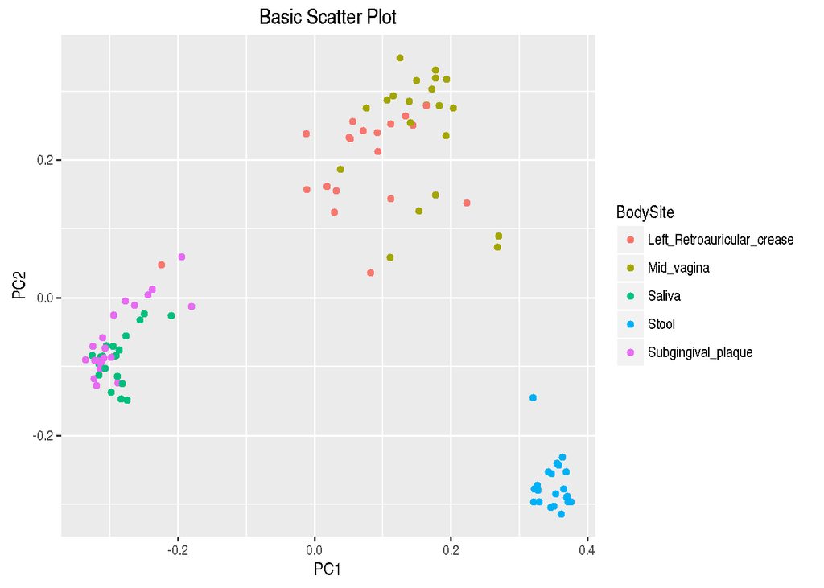

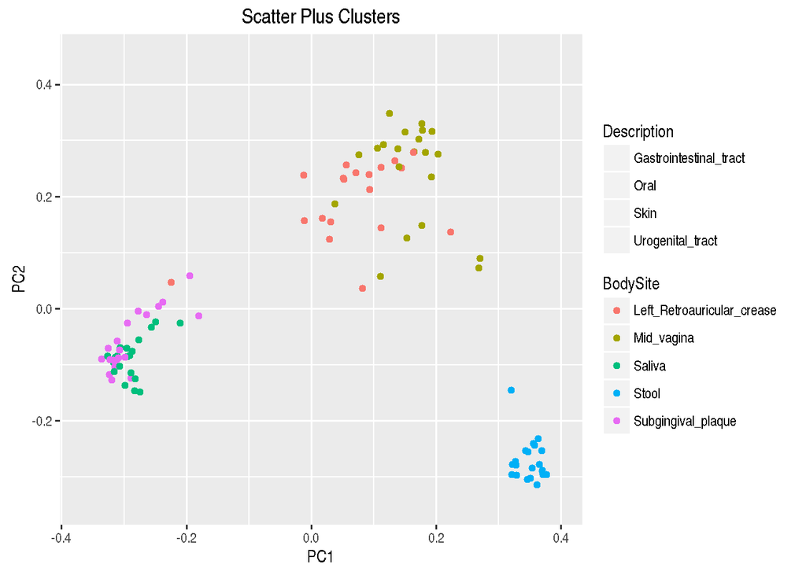

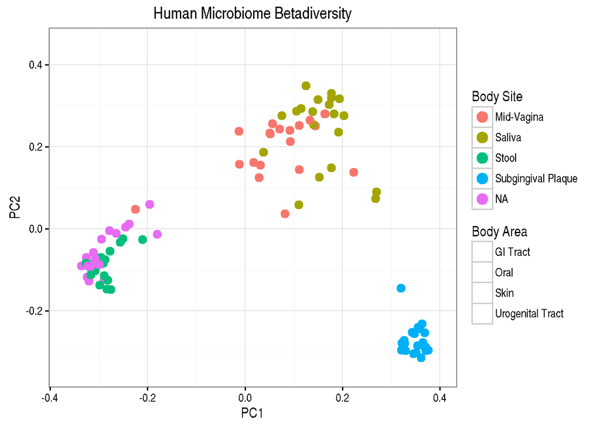

## Adonis

```
##
## Call:
## adonis(formula = beta_dist ~ metadata[, "BodySite"], data = metadata,      permutations = 999)
##
## Permutation: free
## Number of permutations: 999
##
## Terms added sequentially (first to last)
##
##                         Df SumsOfSqs MeanSqs F.Model      R2 Pr(>F)
## metadata[, "BodySite"]   4    12.725  3.1811  15.789 0.39433  0.001 ***
## Residuals               97    19.544  0.2015         0.60567
## Total                  101    32.269                 1.00000
## ---
## Signif. codes:  0 '***' 0.001 '**' 0.01 '*' 0.05 '.' 0.1 ' ' 1
```

## Write output to a table

This section of the code writes the output to a table

```r
#This takes just the analysis of variance table (aoc.tab) from the output
a.table <- ad$aov.tab

#This writes it to a file
write.table(a.table, file="analysis.txt", quote=FALSE, sep="\t", col.names = NA)
```

# Questions

## Question 1

Read the [Beta Diversity QIIME tutorial](https://ay15.moodle.umn.edu/pluginfile.php/1642711/mod_resource/content/0/Beta_Div_QIIME.pdf).

## Question 2

Read the links referenced in the [Beta Diversity in R Tutorial](https://ay15.moodle.umn.edu/pluginfile.php/1642710/mod_resource/content/0/Beta_Div_R.html).

## Question 3

Read the links referenced in the [Beta Diversity in R Tutorial](https://ay15.moodle.umn.edu/pluginfile.php/1642710/mod_resource/content/0/Beta_Div_R.html).

## Question 4

### Question 4a

> beta <- as.matrix(read.table(“unweighted_unifrac_dm.txt”, sep = “”, header=T, row.names = 1, as.is = T, check.names = F))

### Question 4c

Recall this large code block:

> ggplot(PCOA) + stat_ellipse(alpha = 0.3, geom=“polygon”, linetype=“blank”, aes(x = PC1, y = PC2, fill = Description)) + geom_point(size = 3, aes(x = PC1, y = PC2, color = BodySite)) + labs(title=“Human Microbiome Betadiversity”) + scale_color_discrete(name = “Body Site”, labels = c(“Mid-Vagina”, “Saliva”, “Stool”,“Subgingival Plaque”)) + scale_fill_hue(h.start = 20, name = “Body Area”, labels = c(“GI Tract”, “Oral”,“Skin”, “Urogenital Tract”)) + theme(panel.background = element_rect(color = “grey97”), plot.title = element_text(size = 16), axis.title = element_text(size = 14), axis.text = element_text(size = 12), legend.title = element_text(size = 14), legend.text = element_text(size = 12)) + theme_bw() + guides(color = guide_legend(override.aes = list(fill = “grey97”, size = 4)), fill = guide_legend(override.aes=list(shape = NA)) )

The X and Y are defined, you must re-define them appropriately. Make sure the labels remain the same.

### Question 4d

You will re-run the adonis statistical test on the weighted UniFrac and the Bray-Curtis distance matrix, and on the *Description* field rather than *BodySite*. Remember *Description* refers to Body Area.

# One more things

You can re-make the plots for the Weighted matrix and Bray-Curtis data as well. It is interesting to see, and usually only takes a minute (re-running all of the code).